# Finding and obtaining open datasets

### Daniel R. Witte

## Where is Open Data in the Open Science Universe?

- Open data is not primarily about what you can download from the internet

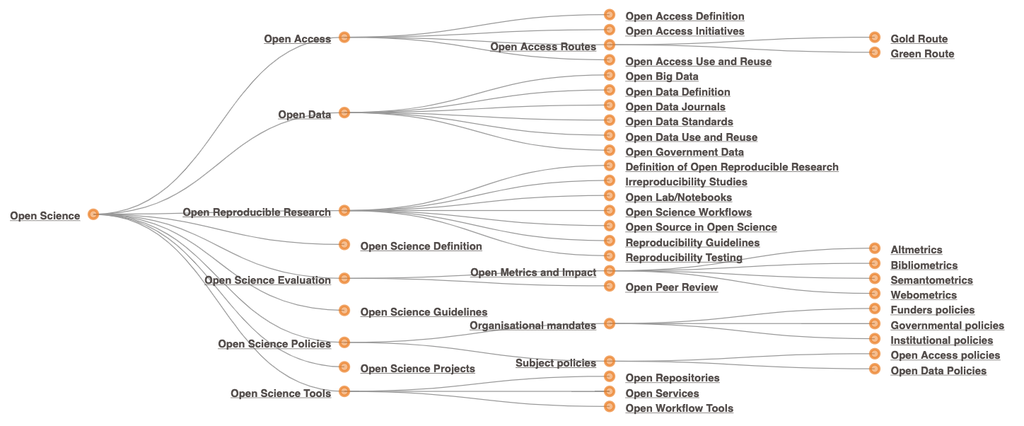

## There are different types of open data

- Open data is not primarily about what you can download from the internet

- Accessibility and Openness are two different things

- In terms of access, data should be FAIR[1]:
  - Findable
  - Accessible
  - Interoperable
  - Reusable

[1] Go FAIR Initiative (https://www.go-fair.org/fair-principles/)

## FAIR data[1]

- Findable: The first step in (re)using data is to find them. Metadata and data should be easy to find for both humans and computers.

- Accessible: Once the user finds the required data, she/he needs to know **how** can they be accessed, possibly including authentication and authorisation.

- Interoperable: The data usually need to interoperate with applications or workflows for analysis, storage, and processing. (Meta)data should use a formal, accessible, shared language or format

- Reusable: Metadata and data should be well-described so that they can be replicated and/or combined in different settings.

[1] Go FAIR Initiative (https://www.go-fair.org/fair-principles/)

## Knowing whether data are open

- First important step: know who 'owns' the data and what you are allowed to do with it
    - Public Domain: There is no owner, you are allowed to use the data in any way
    - Data are protected by copyright: but the owner gives you a license to use it in a certain way

- Different types of licenses
    - MIT
    - Creative Commons
        - CC-BY (only attribution required)
    CC0 (= placing something in the public domain)

## Links and references

- [Go Fair]
- [GitHub]
- [Dryad]
- [figshare]

- [Foster Open Science]
- [Open Science Framework]
- [European Data Portal]
- [Center for Open Science]

## Let's have a look at the PLOS journals

- PLOS journals have a policy requiring researchers to share the data underlying their results and publication
- But: Are authors complying with these requirements?
(https://journals.plos.org/plosone/article?id=10.1371/journal.pone.0194768)